# Trabajo de Investigacion

#Analisis Fcatorial Explorativa sin los desagregados

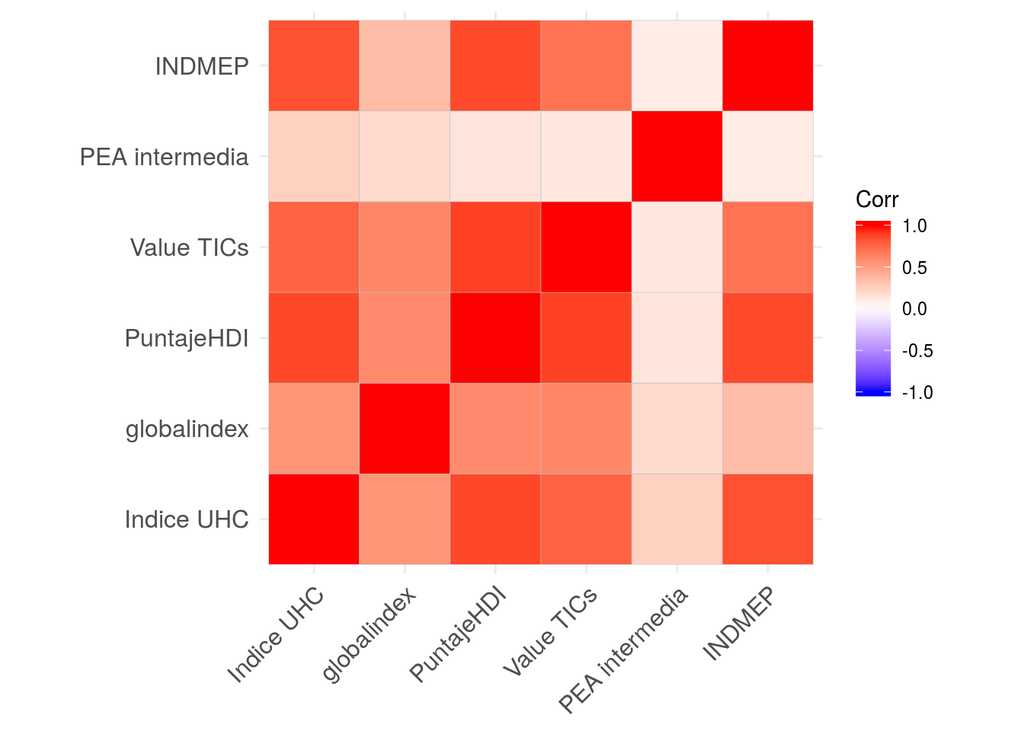

```r
totalAF1=total9[,c(2,3,9,14,15,19)] #sin ISO ni Score GCR, ni desagregados
library(polycor)
corMatrix1=polycor::hetcor(totalAF1)$correlations
library(ggcorrplot)
ggcorrplot(corMatrix1)
```

```r
library(psych)
psych::KMO(corMatrix1)
```

```
## Kaiser-Meyer-Olkin factor adequacy
## Call: psych::KMO(r = corMatrix1)
## Overall MSA =  0.8
## MSA for each item =
##     Indice UHC    globalindex     PuntajeHDI     Value TICs PEA intermedia
##           0.87           0.82           0.76           0.82           0.60
##         INDMEP
##           0.75
```

```r
cortest.bartlett(corMatrix1,n=nrow(totalAF1))$p.value>0.05
```

```
## [1] FALSE
```

```r
library(matrixcalc)

is.singular.matrix(corMatrix1)
```

```
## [1] FALSE
```

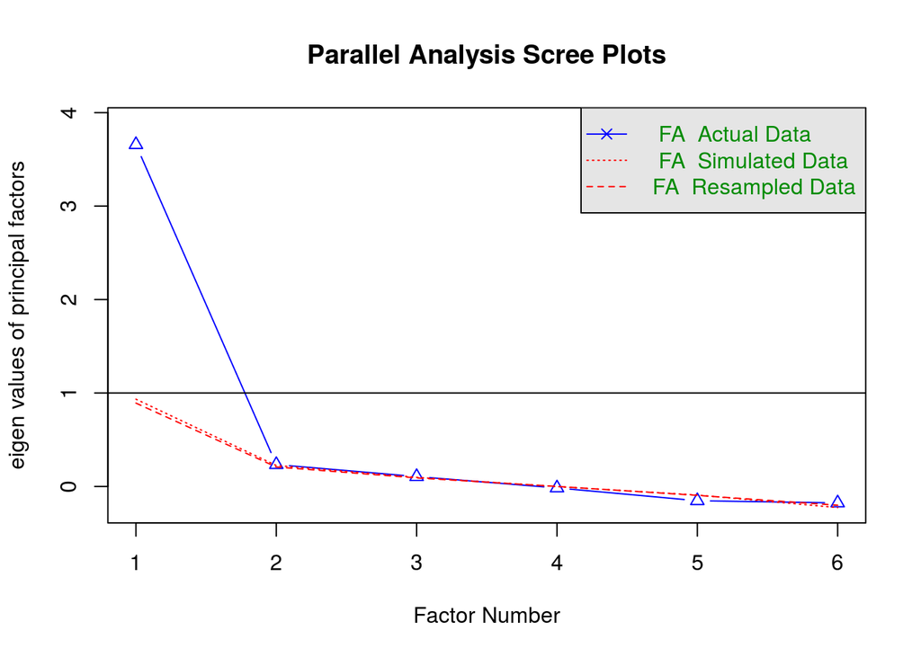

```
## Parallel analysis suggests that the number of factors =  1  and the number of components =  NA
```

```r
fa.parallel(totalAF1,fm = 'ML', fa = 'fa') #para ver a cuantas variables latentes se debe llegar
```

```r
library(GPArotation)
resfa1=fa(totalAF1,nfactors = 1,cor = 'mixed',rotate = "varimax",fm="minres")
```

```
##
## mixed.cor is deprecated, please use mixedCor.
```

```r
print(resfa1$loadings)
```

```
##
## Loadings:
##                MR1
## Indice UHC     0.918
## globalindex    0.585
## PuntajeHDI     0.991
## Value TICs     0.882
## PEA intermedia 0.180
## INDMEP         0.826
##
##                 MR1
## SS loadings    3.66
## Proportion Var 0.61
```

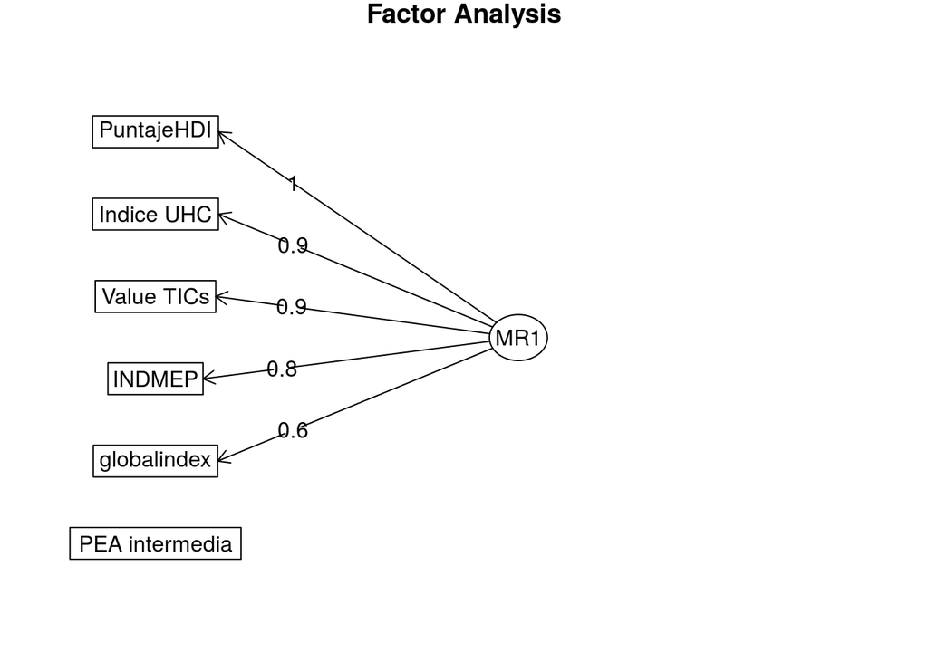

```r
fa.diagram(resfa1) #grafico de lo de arriba
```

```r
resfa1$crms #ver la raiz error cuadrático medio corregida
```

```
## [1] 0.0797728
```

```r
resfa1$RMSEA #ver la raiz error cuacratico medio de aproximacion
```

```
##      RMSEA      lower      upper confidence
##  0.2451093  0.1789531  0.3033598  0.9000000
```

```r
resfa1$TLI #indice Tucker Lewis
```

```
## [1] 0.8232899
```

```r
sort(resfa1$communality) #que variables aportaron más al factor
```

```
## PEA intermedia    globalindex         INDMEP     Value TICs     Indice UHC
##     0.03251418     0.34178183     0.68184697     0.77869755     0.84267237
##     PuntajeHDI
##     0.98210888
```

```r
sort(resfa1$complexity) #a cuantos factores aportan
```

```
##     Indice UHC         INDMEP    globalindex     PuntajeHDI     Value TICs
##              1              1              1              1              1
## PEA intermedia
##              1
```

```r
sort(resfa1$uniquenesses)
```

```
##     PuntajeHDI     Indice UHC     Value TICs         INDMEP    globalindex
##     0.01789112     0.15732763     0.22130245     0.31815303     0.65821817
## PEA intermedia
##     0.96748582
```

#Analisis Factorial Explorativa con los desagregados

```r
totalAF2=total9[,-c(1,3,8,9,19,20)] # sin los Scores ni codigo iso

library(polycor)
corMatrix2=polycor::hetcor(totalAF2)$correlations
```

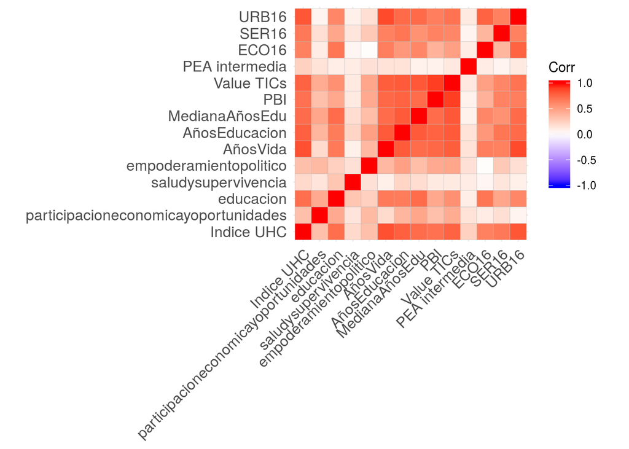

```r
library(ggcorrplot)

ggcorrplot(corMatrix2)
```

```r
library(psych)
psych::KMO(corMatrix2)
```

```
## Kaiser-Meyer-Olkin factor adequacy
## Call: psych::KMO(r = corMatrix2)
## Overall MSA =  0.88
## MSA for each item =
##                           Indice UHC participacioneconomicayoportunidades
##                                 0.92                                 0.75
##                            educacion                  saludysupervivencia
##                                 0.81                                 0.60
##               empoderamientopolitico                             AñosVida
##                                 0.88                                 0.91
##                        AñosEducacion                       MedianaAñosEdu
##                                 0.95                                 0.90
##                                  PBI                           Value TICs
##                                 0.88                                 0.91
##                       PEA intermedia                                ECO16
##                                 0.55                                 0.86
##                                SER16                                URB16
##                                 0.94                                 0.84
```

Segun el KMO, es posible realizar un analisis factorial

```r
cortest.bartlett(corMatrix2,n=nrow(totalAF2))$p.value>0.05 #para ver si es una matriz de identidad o no
```

```
## [1] FALSE
```

```r
library(matrixcalc)

is.singular.matrix(corMatrix2) #para ver si una matriz singular
```

```
## [1] FALSE
```

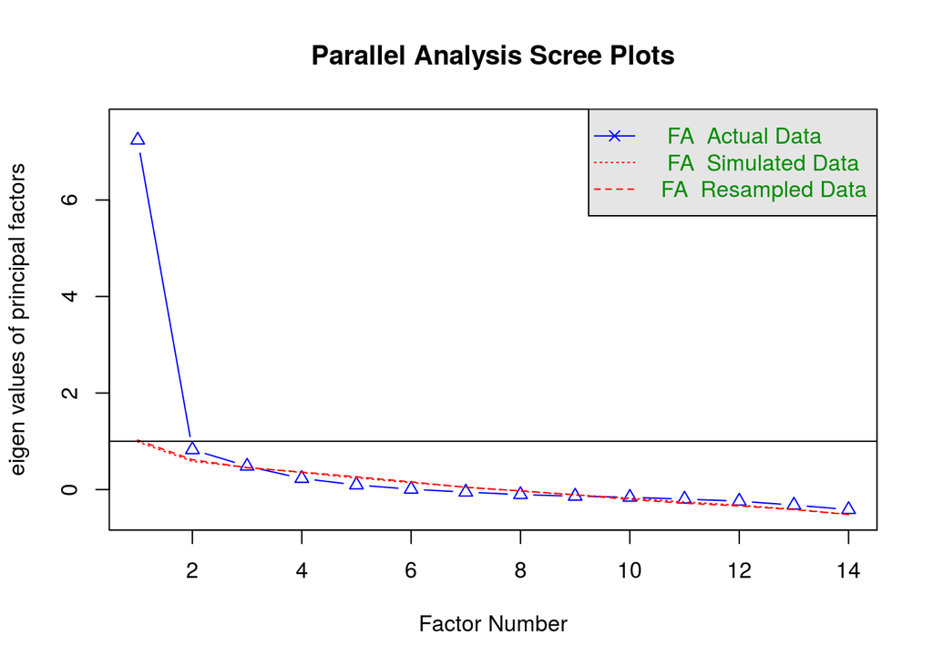

```
## Parallel analysis suggests that the number of factors =  2  and the number of components =  NA
```

```r
fa.parallel(totalAF2,fm = 'ML', fa = 'fa')
```

Según el fa.parallel se nos recomienda 2 variables latentes

```r
library(GPArotation)
resfa2=fa(totalAF2,nfactors =2,cor = 'mixed',rotate = "varimax",fm="minres")
```

```
##
## mixed.cor is deprecated, please use mixedCor.
```

```r
print(resfa2$loadings)
```

```
##
## Loadings:
##                                      MR1    MR2
## Indice UHC                            0.794  0.441
## participacioneconomicayoportunidades         0.556
## educacion                             0.660  0.352
## saludysupervivencia                          0.215
## empoderamientopolitico                       0.648
## AñosVida                              0.826  0.389
## AñosEducacion                         0.666  0.631
## MedianaAñosEdu                        0.698  0.530
## PBI                                   0.563  0.634
## Value TICs                            0.623  0.673
## PEA intermedia                               0.156
## ECO16                                 0.825
## SER16                                 0.579  0.383
## URB16                                 0.961  0.126
##
##                  MR1   MR2
## SS loadings    5.347 2.966
## Proportion Var 0.382 0.212
## Cumulative Var 0.382 0.594
```

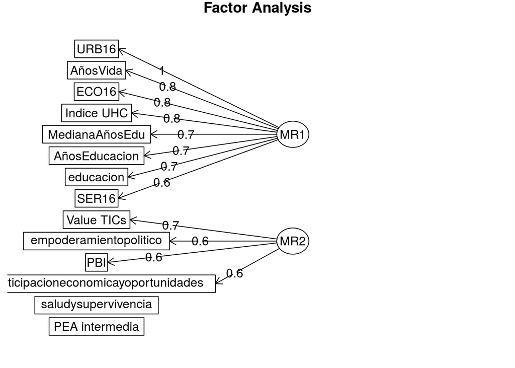

```r
fa.diagram(resfa2)
```

```r
resfa2$crms #ver la raiz error cuadrático medio corregida
```

```
## [1] 0.06781369
```

Está cerca de cero

```r
resfa2$RMSEA #ver la raiz error cuacratico medio de aproximacion
```

```
##      RMSEA      lower      upper confidence
##  0.1522745  0.1176564  0.1682874  0.9000000
```

Es mayor a 0.05

```r
resfa2$TLI #indice Tucker Lewis
```

```
## [1] 0.8309554
```

```r
sort(resfa2$communality) #que variables aportaron más al factor
```

```
##                       PEA intermedia                  saludysupervivencia
##                           0.03086373                           0.05254605
## participacioneconomicayoportunidades               empoderamientopolitico
##                           0.31601433                           0.42486709
##                                SER16                            educacion
##                           0.48122210                           0.55999166
##                                ECO16                                  PBI
##                           0.68114213                           0.71826824
##                       MedianaAñosEdu                           Indice UHC
##                           0.76767345                           0.82473011
##                             AñosVida                           Value TICs
##                           0.83370417                           0.84056511
##                        AñosEducacion                                URB16
##                           0.84232467                           0.93945491
```

```r
sort(resfa2$complexity) #a cuantos factores aportan
```

```
##                                ECO16               empoderamientopolitico
##                             1.001452                             1.021582
##                                URB16 participacioneconomicayoportunidades
##                             1.034287                             1.041711
##                  saludysupervivencia                             AñosVida
##                             1.276953                             1.422118
##                       PEA intermedia                            educacion
##                             1.501451                             1.526355
##                           Indice UHC                                SER16
##                             1.563836                             1.733882
##                       MedianaAñosEdu                                  PBI
##                             1.866330                             1.972427
##                           Value TICs                        AñosEducacion
##                             1.988340                             1.994075
```

```r
sort(resfa2$uniquenesses)
```

```
##                                URB16                        AñosEducacion
##                           0.06054509                           0.15767533
##                           Value TICs                             AñosVida
##                           0.15943489                           0.16629583
##                           Indice UHC                       MedianaAñosEdu
##                           0.17526989                           0.23232655
##                                  PBI                                ECO16
##                           0.28173176                           0.31885787
##                            educacion                                SER16
##                           0.44000834                           0.51877790
##               empoderamientopolitico participacioneconomicayoportunidades
##                           0.57513291                           0.68398567
##                  saludysupervivencia                       PEA intermedia
##                           0.94745395                           0.96913627
```

#Analisis Factorial Confirmativa de GGG

```r
library(psych)
GGG2=GGG[,-c(1,2,7)] # sin score ni nombre de país ni codigo iso

library(GPArotation)
resfa3=fa(GGG2,nfactors = 1,cor = 'mixed',rotate = "varimax",fm="minres")#pese a que no nos sugiere ninguna latente, se opta por ponerle 1
```

```
##
## mixed.cor is deprecated, please use mixedCor.
```

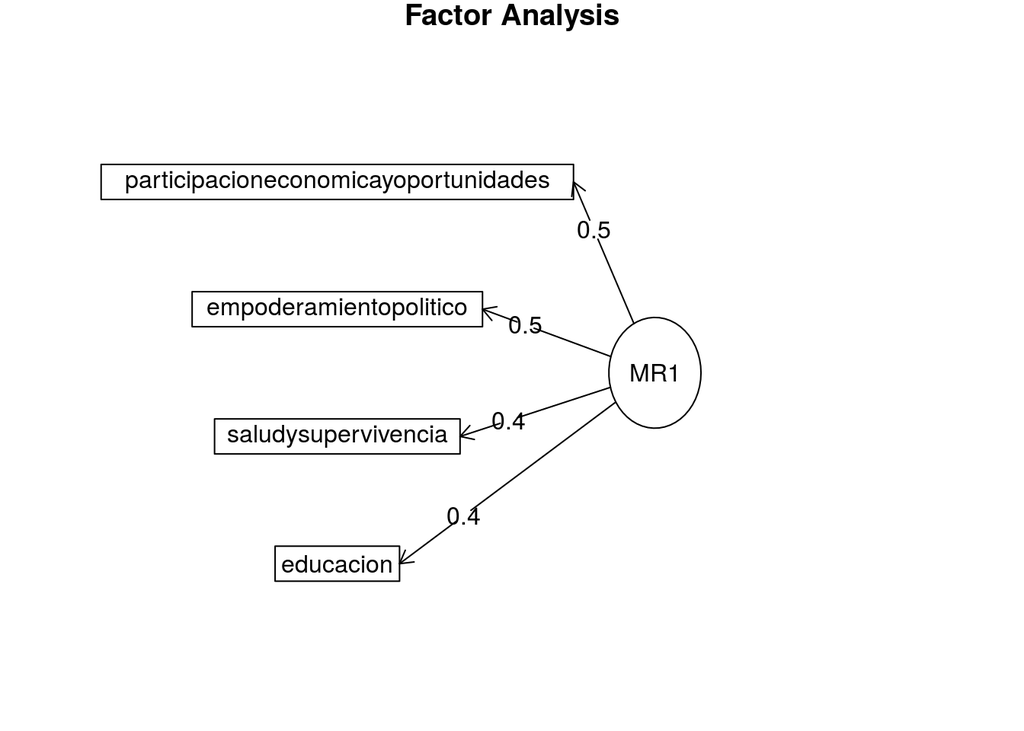

```r
fa.diagram(resfa3)
```

#Confirmando Modelo Teórico

```r
names(total9)
```

```
##  [1] "ISO"
##  [2] "Indice UHC"
##  [3] "globalindex"
##  [4] "participacioneconomicayoportunidades"
##  [5] "educacion"
##  [6] "saludysupervivencia"
##  [7] "empoderamientopolitico"
##  [8] "Score GCR"
##  [9] "PuntajeHDI"
## [10] "AñosVida"
## [11] "AñosEducacion"
## [12] "MedianaAñosEdu"
## [13] "PBI"
## [14] "Value TICs"
## [15] "PEA intermedia"
## [16] "ECO16"
## [17] "SER16"
## [18] "URB16"
## [19] "INDMEP"
## [20] "clusterpar"
```

```r
model2 <- ' ScoreGGG2  =~ participacioneconomicayoportunidades + educacion + saludysupervivencia + empoderamientopolitico'
```

```r
library(lavaan)
cfa_fit9 <- cfa(model2 , data = total8,
           std.lv=TRUE,
           missing="fiml")
allParamCFA9=parameterEstimates(cfa_fit9,standardized = T)
allFitCFA9=as.list(fitMeasures(cfa_fit9))
```

```r
library(knitr)
kable(allParamCFA9[allParamCFA9$op=="=~",])
```

| lhs | op | rhs | est | se | z | pvalue | ci.lower | ci.upper | std.lv | std.all | std.nox |
| --- | --- | --- | --- | --- | --- | --- | --- | --- | --- | --- | --- |
| ScoreGGG2 | =~ | participacioneconomicayoportunidades | 0.0741208 | 0.0162498 | 4.561339 | 0.0000051 | 0.0422718 | 0.1059699 | 0.0741208 | 0.6679488 | 0.6679488 |
| ScoreGGG2 | =~ | educacion | 0.0398340 | 0.0089632 | 4.444176 | 0.0000088 | 0.0222665 | 0.0574016 | 0.0398340 | 0.6521564 | 0.6521564 |
| ScoreGGG2 | =~ | saludysupervivencia | 0.0025055 | 0.0010591 | 2.365768 | 0.0179927 | 0.0004298 | 0.0045812 | 0.0025055 | 0.3286769 | 0.3286769 |
| ScoreGGG2 | =~ | empoderamientopolitico | 0.0627995 | 0.0179519 | 3.498206 | 0.0004684 | 0.0276144 | 0.0979846 | 0.0627995 | 0.4653858 | 0.4653858 |

```r
#ahora veremos el chi square
allFitCFA9[c("chisq", "df", "pvalue")] # pvalue>0.05,
```

```
## $chisq
## [1] 3.348696
##
## $df
## [1] 2
##
## $pvalue
## [1] 0.1874303
```

Tucker Lewis

```r
allFitCFA9$tli # > 0.90
```

```
## [1] 0.8802495
```

La Raíz del error cuadrático medio de aproximación es menor a 0.05?

```r
allFitCFA9[c('rmsea.ci.lower','rmsea' ,'rmsea.ci.upper')] # 0.05 en el Int de Conf?
```

```
## $rmsea.ci.lower
## [1] 0
##
## $rmsea
## [1] 0.08855086
##
## $rmsea.ci.upper
## [1] 0.2490675
```

```r
#Añadimos los índices a la data de indicadores:

total9=as.data.frame(cbind(total9,lavPredict(cfa_fit9)))
```

```r
#vemos si el indice GGG se incluyó en la tabla
summary(total9)
```

```
##      ISO              Indice UHC     globalindex
##  Length:86          Min.   :30.00   Min.   :0.4840
##  Class :character   1st Qu.:62.25   1st Qu.:0.6760
##  Mode  :character   Median :70.00   Median :0.7040
##                     Mean   :67.33   Mean   :0.7038
##                     3rd Qu.:77.75   3rd Qu.:0.7395
##                     Max.   :80.00   Max.   :0.8810
##  participacioneconomicayoportunidades   educacion      saludysupervivencia
##  Min.   :0.2250                       Min.   :0.7200   Min.   :0.9390
##  1st Qu.:0.6162                       1st Qu.:0.9818   1st Qu.:0.9722
##  Median :0.6705                       Median :0.9940   Median :0.9775
##  Mean   :0.6664                       Mean   :0.9706   Mean   :0.9745
##  3rd Qu.:0.7358                       3rd Qu.:1.0000   3rd Qu.:0.9800
##  Max.   :0.8360                       Max.   :1.0000   Max.   :0.9800
##  empoderamientopolitico   Score GCR       PuntajeHDI        AñosVida
##  Min.   :0.02100        Min.   :35.50   Min.   :0.4230   Min.   :54.10
##  1st Qu.:0.09875        1st Qu.:54.50   1st Qu.:0.6967   1st Qu.:71.70
##  Median :0.17750        Median :62.25   Median :0.7895   Median :75.50
##  Mean   :0.20408        Mean   :62.89   Mean   :0.7692   Mean   :74.73
##  3rd Qu.:0.27400        3rd Qu.:70.47   3rd Qu.:0.8708   3rd Qu.:80.53
##  Max.   :0.71900        Max.   :83.70   Max.   :0.9440   Max.   :83.90
##  AñosEducacion   MedianaAñosEdu        PBI          Value TICs
##  Min.   : 7.70   Min.   : 1.500   Min.   : 1239   Min.   :2.500
##  1st Qu.:12.70   1st Qu.: 8.000   1st Qu.: 8571   1st Qu.:3.600
##  Median :14.80   Median :10.200   Median :17702   Median :4.200
##  Mean   :14.41   Mean   : 9.733   Mean   :21427   Mean   :4.238
##  3rd Qu.:16.27   3rd Qu.:12.100   3rd Qu.:30592   3rd Qu.:4.700
##  Max.   :19.80   Max.   :14.100   Max.   :65016   Max.   :6.000
##  PEA intermedia      ECO16           SER16           URB16
##  Min.   :38.50   Min.   :49.60   Min.   :18.30   Min.   : 10.10
##  1st Qu.:59.07   1st Qu.:63.15   1st Qu.:53.83   1st Qu.: 75.85
##  Median :65.36   Median :65.50   Median :67.65   Median : 94.20
##  Mean   :64.30   Mean   :64.50   Mean   :64.74   Mean   : 82.41
##  3rd Qu.:70.40   3rd Qu.:67.42   3rd Qu.:79.75   3rd Qu.: 98.95
##  Max.   :91.70   Max.   :73.80   Max.   :97.90   Max.   :100.00
##      INDMEP        clusterpar     ScoreGGG2
##  Min.   :2.000   Min.   :1.00   Min.   :-3.6010
##  1st Qu.:3.750   1st Qu.:2.00   1st Qu.:-0.1951
##  Median :4.333   Median :2.00   Median : 0.1175
##  Mean   :3.981   Mean   :2.07   Mean   : 0.0000
##  3rd Qu.:4.333   3rd Qu.:2.75   3rd Qu.: 0.4875
##  Max.   :4.667   Max.   :3.00   Max.   : 1.5085
```

Agregaremos la nueva columna cuando hagamos la regresión para analizarla.

##REGRESION BETA

```r
total9$`Score GCR`=total9$`Score GCR`/100
```

```r
names(total9)
```

```
##  [1] "ISO"
##  [2] "Indice UHC"
##  [3] "globalindex"
##  [4] "participacioneconomicayoportunidades"
##  [5] "educacion"
##  [6] "saludysupervivencia"
##  [7] "empoderamientopolitico"
##  [8] "Score GCR"
##  [9] "PuntajeHDI"
## [10] "AñosVida"
## [11] "AñosEducacion"
## [12] "MedianaAñosEdu"
## [13] "PBI"
## [14] "Value TICs"
## [15] "PEA intermedia"
## [16] "ECO16"
## [17] "SER16"
## [18] "URB16"
## [19] "INDMEP"
## [20] "clusterpar"
## [21] "ScoreGGG2"
```

Vamos a hacer una regresión beta con las variables desagregadas

```r
library(betareg)

reg9Data=total9[,c(4,5,6,7,10,11,12,14,15,16,17,18)]
modelBeta9=betareg(total9$`Score GCR`~.,data=reg9Data)
summary(modelBeta9)
```

```
##
## Call:
## betareg(formula = total9$`Score GCR` ~ ., data = reg9Data)
##
## Standardized weighted residuals 2:
##     Min      1Q  Median      3Q     Max
## -3.2832 -0.6740  0.1597  0.7079  2.5117
##
## Coefficients (mean model with logit link):
##                                        Estimate Std. Error z value Pr(>|z|)
## (Intercept)                          -0.5397610  2.2023314  -0.245    0.806
## participacioneconomicayoportunidades  0.0412423  0.2034480   0.203    0.839
## educacion                             0.2553313  0.5011692   0.509    0.610
## saludysupervivencia                  -2.1621946  2.2680127  -0.953    0.340
## empoderamientopolitico                0.0324716  0.1555091   0.209    0.835
## AñosVida                              0.0088980  0.0060536   1.470    0.142
## AñosEducacion                         0.0074710  0.0141496   0.528    0.598
## MedianaAñosEdu                       -0.0078525  0.0132720  -0.592    0.554
## `Value TICs`                          0.5303645  0.0428785  12.369   <2e-16 ***
## `PEA intermedia`                      0.0011152  0.0015936   0.700    0.484
## ECO16                                -0.0009130  0.0059220  -0.154    0.877
## SER16                                 0.0001244  0.0011848   0.105    0.916
## URB16                                -0.0004992  0.0017575  -0.284    0.776
##
## Phi coefficients (precision model with identity link):
##       Estimate Std. Error z value Pr(>|z|)
## (phi)   207.99      31.65   6.572 4.98e-11 ***
## ---
## Signif. codes:  0 '***' 0.001 '**' 0.01 '*' 0.05 '.' 0.1 ' ' 1
##
## Type of estimator: ML (maximum likelihood)
## Log-likelihood: 173.1 on 14 Df
## Pseudo R-squared: 0.918
## Number of iterations: 30 (BFGS) + 3 (Fisher scoring)
```

Ahora probaremos con solo los indices

```r
reg9Dataindi=total9[,c(2,3,9,14,15,16,17,18,21)]
modelBeta9indi=betareg(total9$`Score GCR`~.,data=reg9Dataindi)
summary(modelBeta9indi)
```

```
##
## Call:
## betareg(formula = total9$`Score GCR` ~ ., data = reg9Dataindi)
##
## Standardized weighted residuals 2:
##     Min      1Q  Median      3Q     Max
## -3.3978 -0.7427  0.0969  0.7077  2.7138
##
## Coefficients (mean model with logit link):
##                    Estimate Std. Error z value Pr(>|z|)
## (Intercept)      -2.8557279  0.7559764  -3.778 0.000158 ***
## `Indice UHC`      0.0024310  0.0028547   0.852 0.394447
## globalindex       0.7096364  0.8644110   0.821 0.411676
## PuntajeHDI        1.1728109  0.4594340   2.553 0.010688 *
## `Value TICs`      0.4679947  0.0452935  10.332  < 2e-16 ***
## `PEA intermedia`  0.0008323  0.0015853   0.525 0.599576
## ECO16             0.0010017  0.0053917   0.186 0.852614
## SER16            -0.0007452  0.0012092  -0.616 0.537692
## URB16            -0.0024814  0.0018723  -1.325 0.185061
## ScoreGGG2        -0.0793521  0.0652890  -1.215 0.224215
##
## Phi coefficients (precision model with identity link):
##       Estimate Std. Error z value Pr(>|z|)
## (phi)   212.68      32.37   6.571 4.99e-11 ***
## ---
## Signif. codes:  0 '***' 0.001 '**' 0.01 '*' 0.05 '.' 0.1 ' ' 1
##
## Type of estimator: ML (maximum likelihood)
## Log-likelihood: 174.1 on 11 Df
## Pseudo R-squared: 0.9203
## Number of iterations: 24 (BFGS) + 3 (Fisher scoring)
```

Ahoro solo los significativos

```r
reg9DataTicsIDH=total9[,c(9,14)]
modelBeta9TicsIDH=betareg(total9$`Score GCR`~.,data=reg9DataTicsIDH)
summary(modelBeta9TicsIDH)
```

```
##
## Call:
## betareg(formula = total9$`Score GCR` ~ ., data = reg9DataTicsIDH)
##
## Standardized weighted residuals 2:
##     Min      1Q  Median      3Q     Max
## -3.4460 -0.7697  0.0964  0.7583  2.2761
##
## Coefficients (mean model with logit link):
##              Estimate Std. Error z value Pr(>|z|)
## (Intercept)  -2.03841    0.09384 -21.722   <2e-16 ***
## PuntajeHDI    0.64848    0.25866   2.507   0.0122 *
## `Value TICs`  0.49489    0.04270  11.589   <2e-16 ***
##
## Phi coefficients (precision model with identity link):
##       Estimate Std. Error z value Pr(>|z|)
## (phi)   203.12      30.91   6.572 4.97e-11 ***
## ---
## Signif. codes:  0 '***' 0.001 '**' 0.01 '*' 0.05 '.' 0.1 ' ' 1
##
## Type of estimator: ML (maximum likelihood)
## Log-likelihood: 172.1 on 4 Df
## Pseudo R-squared: 0.9166
## Number of iterations: 27 (BFGS) + 2 (Fisher scoring)
```